# Assignment 2

Author

Patrick Casanas

Published

October 10, 2024

# **Data Wrangling**

```r
library(dplyr)
library(readr)
library(ggplot2)
library(leaflet)
```

## Part 1

```r
chs_individual <- read_csv("chs_individual.csv")
chs_regional <- read_csv("chs_regional.csv")
```

```r
merged_chs <- merge(chs_individual, chs_regional, by="townname", all.x=TRUE)
```

```r
nrow(merged_chs)
```

```
[1] 1200
```

```r
merged_chs <- merged_chs %>%
  group_by(male, hispanic) %>%
  mutate(
    agepft = ifelse(is.na(agepft), mean(agepft, na.rm=TRUE), agepft),
    height = ifelse(is.na(height), mean(height, na.rm=TRUE), height),
    weight = ifelse(is.na(weight), mean(weight, na.rm=TRUE), weight),
    bmi = ifelse(is.na(bmi), mean(bmi, na.rm=TRUE), bmi),
    fev = ifelse(is.na(fev), mean(fev, na.rm=TRUE), fev),
    pm25_mass = ifelse(is.na(pm25_mass), mean(pm25_mass, na.rm=TRUE), pm25_mass)
  ) %>%
  ungroup()


asthma_mode <- merged_chs %>%
  group_by(male, hispanic) %>%
  summarize(asthma_mode = as.numeric(names(which.max(table(asthma)))))
merged_chs <- merged_chs %>%
  left_join(asthma_mode, by = c("male", "hispanic")) %>%
  mutate(asthma = ifelse(is.na(asthma), asthma_mode, asthma)) %>%
  select(-asthma_mode)

smoke_mode <- merged_chs %>%
  group_by(male, hispanic) %>%
  summarize(smoke_mode = as.numeric(names(which.max(table(smoke)))))
merged_chs <- merged_chs %>%
  left_join(smoke_mode, by = c("male", "hispanic")) %>%
  mutate(smoke = ifelse(is.na(smoke), smoke_mode, smoke)) %>%
  select(-smoke_mode)

gasstove_mode <- merged_chs %>%
  group_by(male, hispanic) %>%
  summarize(gasstove_mode = as.numeric(names(which.max(table(gasstove)))))
merged_chs <- merged_chs %>%
  left_join(gasstove_mode, by = c("male", "hispanic")) %>%
  mutate(gasstove = ifelse(is.na(gasstove), gasstove_mode, gasstove)) %>%
  select(-gasstove_mode)
```

```r
sum(is.na(merged_chs$agepft))
```

```
[1] 0
```

```r
sum(is.na(merged_chs$height))
```

```
[1] 0
```

```r
sum(is.na(merged_chs$weight))
```

```
[1] 0
```

```r
sum(is.na(merged_chs$bmi))
```

```
[1] 0
```

```r
sum(is.na(merged_chs$fev))
```

```
[1] 0
```

```r
sum(is.na(merged_chs$asthma))
```

```
[1] 0
```

```r
sum(is.na(merged_chs$smoke))
```

```
[1] 0
```

```r
sum(is.na(merged_chs$gasstove))
```

```
[1] 0
```

## Question 2

```r
merged_chs$obesity_level <- ifelse(merged_chs$bmi < 14, "Underweight",
                                   ifelse(merged_chs$bmi >= 14 & merged_chs$bmi <= 22, "Normal",
                                          ifelse(merged_chs$bmi > 22 & merged_chs$bmi <= 24, "Overweight",
                                                 "Obese")))
head(merged_chs[, c("sid", "bmi", "obesity_level")])
```

```
# A tibble: 6 × 3
    sid   bmi obesity_level
  <dbl> <dbl> <chr>
1   841  15.8 Normal
2   835  15.3 Normal
3   838  15.9 Normal
4   840  16.6 Normal
5   865  24.2 Obese
6   867  21.5 Normal
```

```r
bmi_summary_table <- merged_chs %>%
  group_by(obesity_level) %>%
  summarize(
    min_bmi = min(bmi, na.rm = TRUE),
    max_bmi = max(bmi, na.rm = TRUE),
    count = n()
  )

print(bmi_summary_table)
```

```
# A tibble: 4 × 4
  obesity_level min_bmi max_bmi count
  <chr>           <dbl>   <dbl> <int>
1 Normal           14.0    22.0   975
2 Obese            24.0    41.3   103
3 Overweight       22.0    24.0    87
4 Underweight      11.3    14.0    35
```

## Question 3

```r
merged_chs$smoke_gas_exposure <- ifelse(merged_chs$smoke == 0 & merged_chs$gasstove == 0, "None",
                                 ifelse(merged_chs$smoke == 1 & merged_chs$gasstove == 0, "Secondhand Smoke Only",
                                 ifelse(merged_chs$smoke == 0 & merged_chs$gasstove == 1, "Gas Stove Only",
                                 "Both")))
head(merged_chs[, c("sid", "smoke", "gasstove",  "smoke_gas_exposure")])
```

```
# A tibble: 6 × 4
    sid smoke gasstove smoke_gas_exposure
  <dbl> <dbl>    <dbl> <chr>
1   841     0        0 None
2   835     0        0 None
3   838     0        0 None
4   840     0        1 Gas Stove Only
5   865     0        1 Gas Stove Only
6   867     0        1 Gas Stove Only
```

```r
summary_table_smoke <- merged_chs %>%
  group_by(smoke_gas_exposure) %>%
  summarize(count = n())

print(summary_table_smoke)
```

```
# A tibble: 4 × 2
  smoke_gas_exposure    count
  <chr>                 <int>
1 Both                    154
2 Gas Stove Only          791
3 None                    219
4 Secondhand Smoke Only    36
```

## Question 4

```r
summary_town <- merged_chs %>%
  group_by(townname) %>%
  summarize(
    mean_fev = mean(fev, na.rm = TRUE),
    sd_fev = sd(fev, na.rm = TRUE)
  )

print(summary_town)
```

```
# A tibble: 12 × 3
   townname      mean_fev sd_fev
   <chr>            <dbl>  <dbl>
 1 Alpine           2087.   291.
 2 Atascadero       2076.   324.
 3 Lake Elsinore    2039.   304.
 4 Lake Gregory     2085.   320.
 5 Lancaster        2003.   317.
 6 Lompoc           2034.   351.
 7 Long Beach       1986.   319.
 8 Mira Loma        1985.   325.
 9 Riverside        1990.   278.
10 San Dimas        2027.   319.
11 Santa Maria      2026.   312.
12 Upland           2024.   343.
```

```r
summary_sex <- merged_chs %>%
  group_by(male) %>%
  summarize(
    mean_fev = mean(fev, na.rm = TRUE),
    sd_fev = sd(fev, na.rm = TRUE)
  )

print(summary_sex)
```

```
# A tibble: 2 × 3
   male mean_fev sd_fev
  <dbl>    <dbl>  <dbl>
1     0    1959.   312.
2     1    2104.   308.
```

```r
summary_obesity <- merged_chs %>%
  group_by(obesity_level) %>%
  summarize(
    mean_fev = mean(fev, na.rm = TRUE),
    sd_fev = sd(fev, na.rm = TRUE)
  )

print(summary_obesity)
```

```
# A tibble: 4 × 3
  obesity_level mean_fev sd_fev
  <chr>            <dbl>  <dbl>
1 Normal           2000.   295.
2 Obese            2266.   325.
3 Overweight       2224.   317.
4 Underweight      1698.   303.
```

```r
summary_smoke_gas <- merged_chs %>%
  group_by(smoke_gas_exposure) %>%
  summarize(
    mean_fev = mean(fev, na.rm = TRUE),
    sd_fev = sd(fev, na.rm = TRUE)
  )

print(summary_smoke_gas)
```

```
# A tibble: 4 × 3
  smoke_gas_exposure    mean_fev sd_fev
  <chr>                    <dbl>  <dbl>
1 Both                     2025.   301.
2 Gas Stove Only           2023.   319.
3 None                     2057.   329.
4 Secondhand Smoke Only    2056.   296.
```

# Looking at the Data (EDA)

1. **Read in the data**
2. **Check the size of the data**

   ```r
   dim(merged_chs)
   ```

   ```
   [1] 1200   51
   ```

3. **Examine the variables and their types**

   ```r
   str(merged_chs)
   ```

   ```
   tibble [1,200 × 51] (S3: tbl_df/tbl/data.frame)
    $ townname          : chr [1:1200] "Alpine" "Alpine" "Alpine" "Alpine" ...
    $ sid               : num [1:1200] 841 835 838 840 865 867 842 839 844 847 ...
    $ male              : num [1:1200] 1 0 0 0 0 0 1 0 1 1 ...
    $ race              : chr [1:1200] "W" "W" "O" "W" ...
    $ hispanic          : num [1:1200] 1 0 1 0 0 1 1 1 1 0 ...
    $ agepft            : num [1:1200] 10.55 10.1 9.49 9.97 10.04 ...
    $ height            : num [1:1200] 150 143 133 146 162 141 139 142 143 137 ...
    $ weight            : num [1:1200] 78 69 62 78 140 94 65 86 65 69 ...
    $ bmi               : num [1:1200] 15.8 15.3 15.9 16.6 24.2 ...
    $ asthma            : num [1:1200] 0 0 0 0 1 0 0 0 0 0 ...
    $ active_asthma     : num [1:1200] 0 0 0 0 1 0 0 0 0 0 ...
    $ father_asthma     : num [1:1200] 0 0 0 0 0 NA 0 0 NA 0 ...
    $ mother_asthma     : num [1:1200] 0 0 0 0 0 0 0 1 NA 0 ...
    $ wheeze            : num [1:1200] 0 0 0 0 1 0 1 1 NA 0 ...
   ```

   [output cut: 37 more lines]

4. **Look at the top and bottom of the data**

   ```r
   head(merged_chs)
   ```

   ```
   # A tibble: 6 × 51
     townname   sid  male race  hispanic agepft height weight   bmi asthma
     <chr>    <dbl> <dbl> <chr>    <dbl>  <dbl>  <dbl>  <dbl> <dbl>  <dbl>
   1 Alpine     841     1 W            1  10.5     150     78  15.8      0
   2 Alpine     835     0 W            0  10.1     143     69  15.3      0
   3 Alpine     838     0 O            1   9.49    133     62  15.9      0
   4 Alpine     840     0 W            0   9.97    146     78  16.6      0
   5 Alpine     865     0 W            0  10.0     162    140  24.2      1
   6 Alpine     867     0 W            1   9.96    141     94  21.5      0
   # ℹ 41 more variables: active_asthma <dbl>, father_asthma <dbl>,
   #   mother_asthma <dbl>, wheeze <dbl>, hayfever <dbl>, allergy <dbl>,
   #   educ_parent <dbl>, smoke <dbl>, pets <dbl>, gasstove <dbl>, fev <dbl>,
   #   fvc <dbl>, mmef <dbl>, pm25_mass <dbl>, pm25_so4 <dbl>, pm25_no3 <dbl>,
   #   pm25_nh4 <dbl>, pm25_oc <dbl>, pm25_ec <dbl>, pm25_om <dbl>, pm10_oc <dbl>,
   #   pm10_ec <dbl>, pm10_tc <dbl>, formic <dbl>, acetic <dbl>, hcl <dbl>,
   #   hno3 <dbl>, o3_max <dbl>, o3106 <dbl>, o3_24 <dbl>, no2 <dbl>, …
   ```

   ```r
   tail(merged_chs)
   ```

   ```
   # A tibble: 6 × 51
     townname   sid  male race  hispanic agepft height weight   bmi asthma
     <chr>    <dbl> <dbl> <chr>    <dbl>  <dbl>  <dbl>  <dbl> <dbl>  <dbl>
   1 Upland    1866     0 O            1   9.81   139    60    14.1      0
   2 Upland    1867     0 M            1   9.62   140    71    16.5      0
   3 Upland    2033     0 M            0  10.1    130    67    18.0      0
   4 Upland    2031     1 W            0   9.80   135    83    20.7      0
   5 Upland    2032     1 W            0   9.55   137    59    14.3      0
   6 Upland    2053     0 W            0   9.85   139.   77.4  18.1      0
   # ℹ 41 more variables: active_asthma <dbl>, father_asthma <dbl>,
   #   mother_asthma <dbl>, wheeze <dbl>, hayfever <dbl>, allergy <dbl>,
   #   educ_parent <dbl>, smoke <dbl>, pets <dbl>, gasstove <dbl>, fev <dbl>,
   #   fvc <dbl>, mmef <dbl>, pm25_mass <dbl>, pm25_so4 <dbl>, pm25_no3 <dbl>,
   #   pm25_nh4 <dbl>, pm25_oc <dbl>, pm25_ec <dbl>, pm25_om <dbl>, pm10_oc <dbl>,
   #   pm10_ec <dbl>, pm10_tc <dbl>, formic <dbl>, acetic <dbl>, hcl <dbl>,
   #   hno3 <dbl>, o3_max <dbl>, o3106 <dbl>, o3_24 <dbl>, no2 <dbl>, …
   ```

### What is the association between BMI and FEV?

```r
names(merged_chs)
```

```
 [1] "townname"           "sid"                "male"
 [4] "race"               "hispanic"           "agepft"
 [7] "height"             "weight"             "bmi"
[10] "asthma"             "active_asthma"      "father_asthma"
[13] "mother_asthma"      "wheeze"             "hayfever"
[16] "allergy"            "educ_parent"        "smoke"
[19] "pets"               "gasstove"           "fev"
[22] "fvc"                "mmef"               "pm25_mass"
[25] "pm25_so4"           "pm25_no3"           "pm25_nh4"
[28] "pm25_oc"            "pm25_ec"            "pm25_om"
[31] "pm10_oc"            "pm10_ec"            "pm10_tc"
[34] "formic"             "acetic"             "hcl"
[37] "hno3"               "o3_max"             "o3106"
[40] "o3_24"              "no2"                "pm10"
[43] "no_24hr"            "pm2_5_fr"           "iacid"
[46] "oacid"              "total_acids"        "lon"
[49] "lat"                "obesity_level"      "smoke_gas_exposure"
```

```r
# Check the structure and content of merged_chs before chunk 20
str(merged_chs)
```

```
tibble [1,200 × 51] (S3: tbl_df/tbl/data.frame)
 $ townname          : chr [1:1200] "Alpine" "Alpine" "Alpine" "Alpine" ...
 $ sid               : num [1:1200] 841 835 838 840 865 867 842 839 844 847 ...
 $ male              : num [1:1200] 1 0 0 0 0 0 1 0 1 1 ...
 $ race              : chr [1:1200] "W" "W" "O" "W" ...
 $ hispanic          : num [1:1200] 1 0 1 0 0 1 1 1 1 0 ...
 $ agepft            : num [1:1200] 10.55 10.1 9.49 9.97 10.04 ...
 $ height            : num [1:1200] 150 143 133 146 162 141 139 142 143 137 ...
 $ weight            : num [1:1200] 78 69 62 78 140 94 65 86 65 69 ...
 $ bmi               : num [1:1200] 15.8 15.3 15.9 16.6 24.2 ...
 $ asthma            : num [1:1200] 0 0 0 0 1 0 0 0 0 0 ...
 $ active_asthma     : num [1:1200] 0 0 0 0 1 0 0 0 0 0 ...
 $ father_asthma     : num [1:1200] 0 0 0 0 0 NA 0 0 NA 0 ...
 $ mother_asthma     : num [1:1200] 0 0 0 0 0 0 0 1 NA 0 ...
 $ wheeze            : num [1:1200] 0 0 0 0 1 0 1 1 NA 0 ...
```

[output cut: 37 more lines]

```r
head(merged_chs)
```

```
# A tibble: 6 × 51
  townname   sid  male race  hispanic agepft height weight   bmi asthma
  <chr>    <dbl> <dbl> <chr>    <dbl>  <dbl>  <dbl>  <dbl> <dbl>  <dbl>
1 Alpine     841     1 W            1  10.5     150     78  15.8      0
2 Alpine     835     0 W            0  10.1     143     69  15.3      0
3 Alpine     838     0 O            1   9.49    133     62  15.9      0
4 Alpine     840     0 W            0   9.97    146     78  16.6      0
5 Alpine     865     0 W            0  10.0     162    140  24.2      1
6 Alpine     867     0 W            1   9.96    141     94  21.5      0
# ℹ 41 more variables: active_asthma <dbl>, father_asthma <dbl>,
#   mother_asthma <dbl>, wheeze <dbl>, hayfever <dbl>, allergy <dbl>,
#   educ_parent <dbl>, smoke <dbl>, pets <dbl>, gasstove <dbl>, fev <dbl>,
#   fvc <dbl>, mmef <dbl>, pm25_mass <dbl>, pm25_so4 <dbl>, pm25_no3 <dbl>,
#   pm25_nh4 <dbl>, pm25_oc <dbl>, pm25_ec <dbl>, pm25_om <dbl>, pm10_oc <dbl>,
#   pm10_ec <dbl>, pm10_tc <dbl>, formic <dbl>, acetic <dbl>, hcl <dbl>,
#   hno3 <dbl>, o3_max <dbl>, o3106 <dbl>, o3_24 <dbl>, no2 <dbl>, …
```

```r
# Correlation between BMI and FEV1
correlation_result <- cor(merged_chs$bmi, merged_chs$fev, use = "complete.obs")
print(paste("Correlation between BMI and FEV:", correlation_result))
```

```
[1] "Correlation between BMI and FEV: 0.357112030981777"
```

```r
# Linear regression model: FEV1 as a function of BMI
lm_bmi_fev <- lm(fev ~ bmi, data = merged_chs)
print(summary(lm_bmi_fev))
```

```
Call:
lm(formula = fev ~ bmi, data = merged_chs)

Residuals:
    Min      1Q  Median      3Q     Max
-989.47 -193.88  -11.32  179.43 1305.46

Coefficients:
            Estimate Std. Error t value Pr(>|t|)
(Intercept)  1452.46      44.49   32.65   <2e-16 ***
bmi            31.23       2.36   13.23   <2e-16 ***
---
Signif. codes:  0 '***' 0.001 '**' 0.01 '*' 0.05 '.' 0.1 ' ' 1

Residual standard error: 297.2 on 1198 degrees of freedom
Multiple R-squared:  0.1275,    Adjusted R-squared:  0.1268
F-statistic: 175.1 on 1 and 1198 DF,  p-value: < 2.2e-16
```

There is a slight positive association between BMI and FEV1, meaning that as BMI increases, FEV1 is expected to increase. Based on the regression p-value <0.001, it can be concluded that BMI is a statistically significant predictor of FEV1. The R^2 value however is quite low so only 12.68% of the variation in FEV1 can be attributed to BMI.

### What is the association between smoke and gas exposure and FEV?

```r
merged_chs$smoke_gas_exposure <- ifelse(merged_chs$smoke == 0 & merged_chs$gasstove == 0, "None",
                              ifelse(merged_chs$smoke == 1 & merged_chs$gasstove == 0, "Secondhand Smoke Only",
                              ifelse(merged_chs$smoke == 0 & merged_chs$gasstove == 1, "Gas Stove Only",
                              "Both")))
```

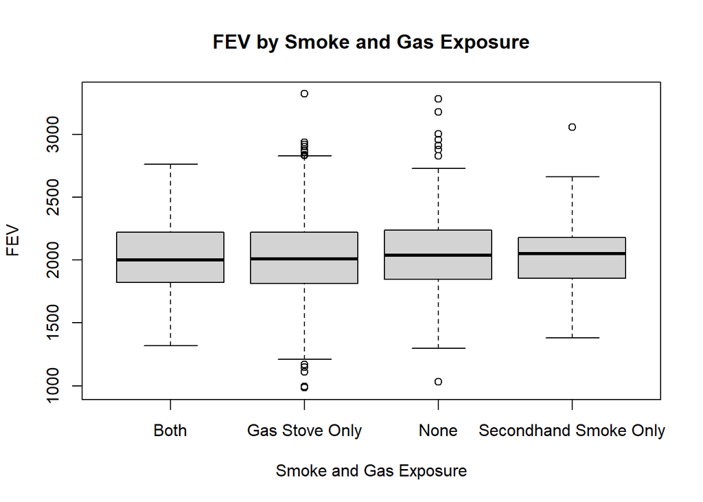

```r
boxplot(fev ~ smoke_gas_exposure, data = merged_chs,
        main = "FEV by Smoke and Gas Exposure",
        xlab = "Smoke and Gas Exposure", ylab = "FEV")
```

```r
anova_smoke_gas <- aov(fev ~ smoke_gas_exposure, data = merged_chs)
summary(anova_smoke_gas)
```

```
                     Df    Sum Sq Mean Sq F value Pr(>F)
smoke_gas_exposure    3    226515   75505   0.746  0.525
Residuals          1196 121017980  101186
```

Based on the box plots there does not seem to be much difference between all 4 groups. After running an ANOVA, this confirms that there appears to be no difference between the groups with a p-value of 0.525. So we can state that there is no statistically significant association between smoke exposure and FEV1.

### What is the association between PM2.5 exposure and FEV1?

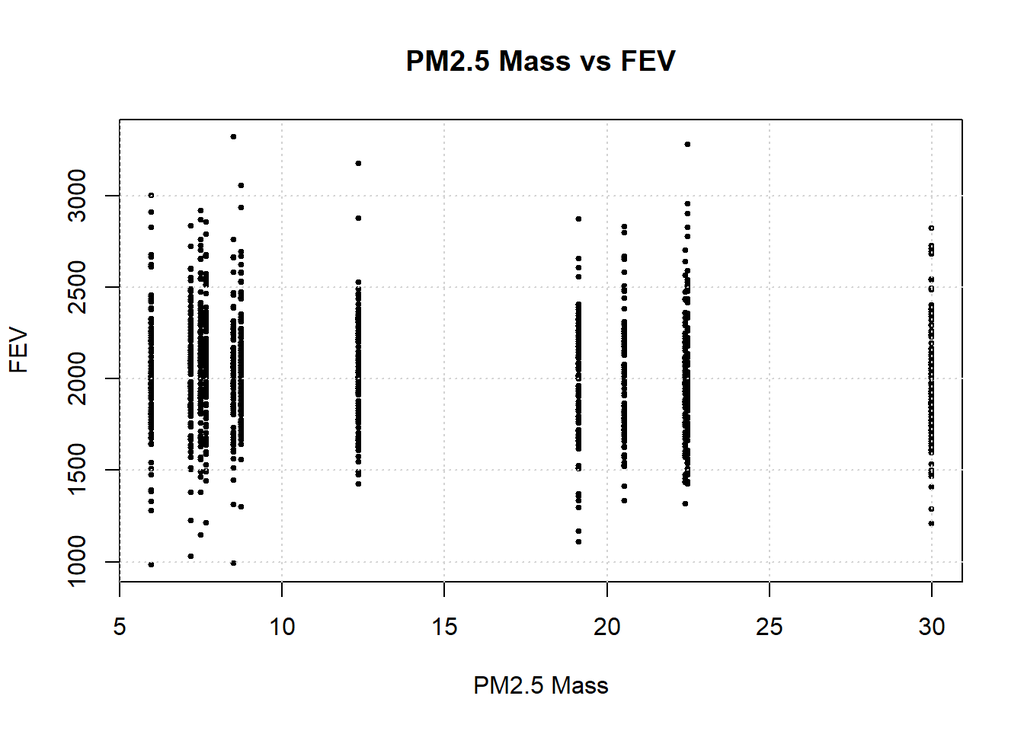

```r
plot(merged_chs$pm25_mass, merged_chs$fev,
     xlab = "PM2.5 Mass", ylab = "FEV",
     main = "PM2.5 Mass vs FEV",
     pch = 19, cex = 0.5)
grid()
```

```r
correlation_result <- cor(merged_chs$pm25_mass, merged_chs$fev, use = "complete.obs")
print(paste("Correlation between PM2.5 mass and FEV:", correlation_result))
```

```
[1] "Correlation between PM2.5 mass and FEV: -0.0734131664601442"
```

```r
lm_pm25_fev <- lm(fev ~ pm25_mass, data = merged_chs)
summary(lm_pm25_fev)
```

```
Call:
lm(formula = fev ~ pm25_mass, data = merged_chs)

Residuals:
     Min       1Q   Median       3Q      Max
-1070.63  -206.57   -13.33   195.87  1277.65

Coefficients:
            Estimate Std. Error t value Pr(>|t|)
(Intercept) 2073.452     19.309 107.383   <2e-16 ***
pm25_mass     -3.016      1.184  -2.548    0.011 *
---
Signif. codes:  0 '***' 0.001 '**' 0.01 '*' 0.05 '.' 0.1 ' ' 1

Residual standard error: 317.3 on 1198 degrees of freedom
Multiple R-squared:  0.005389,  Adjusted R-squared:  0.004559
F-statistic: 6.492 on 1 and 1198 DF,  p-value: 0.01096
```

With a correlation coefficient between PM2.5 and FEV1 of -0.0734, it shows a very weak negative relationship that is almost 0. The p-value of 0.011 for PM2.5 on FEV1 is statistically signficant which means that it is a good predictor of FEV1 but the effect is very small given the correlation coefficient. The R^2 value of 0.0054 indicates that only 0.54% of the variation in FEV1 is attributable to PM2.5.

# Visualization

### Part 1

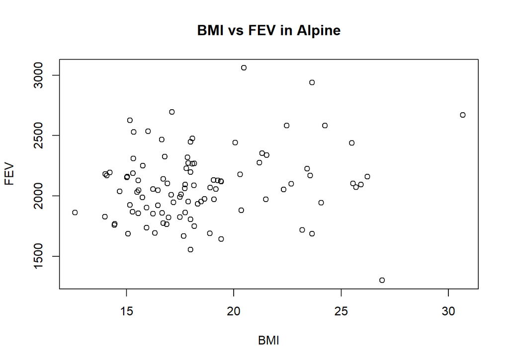

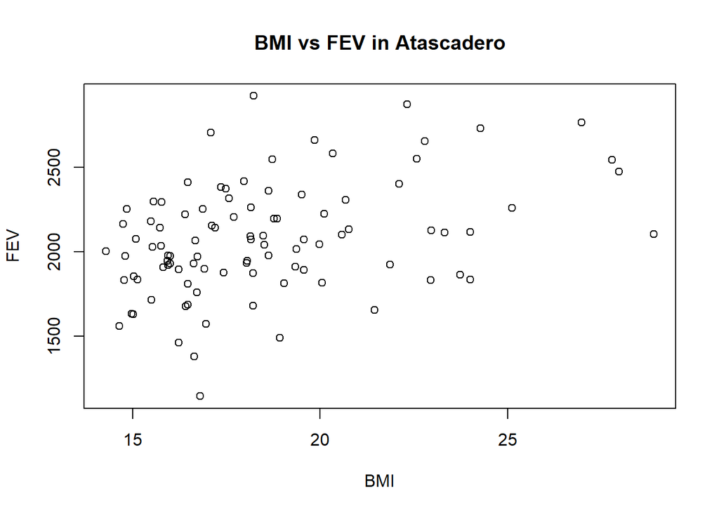

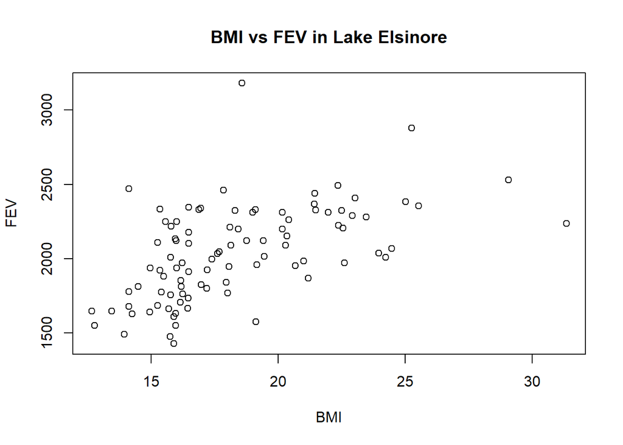

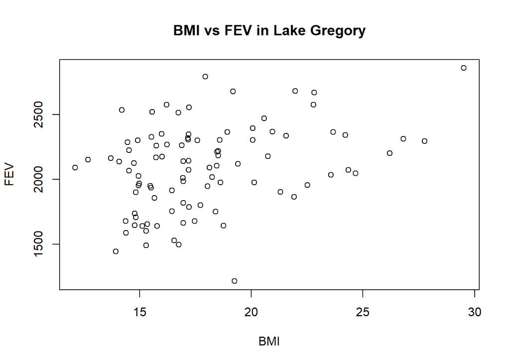

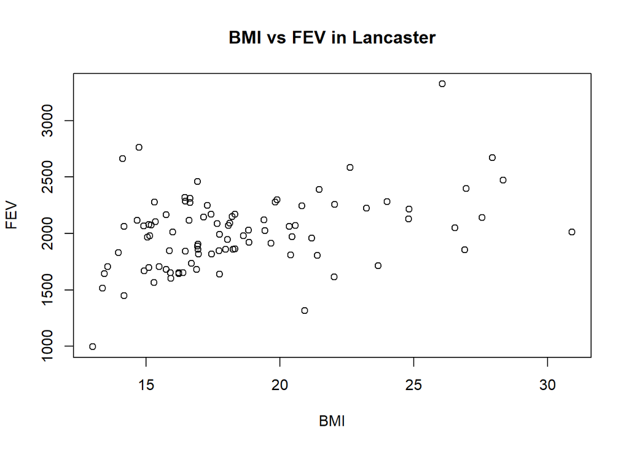

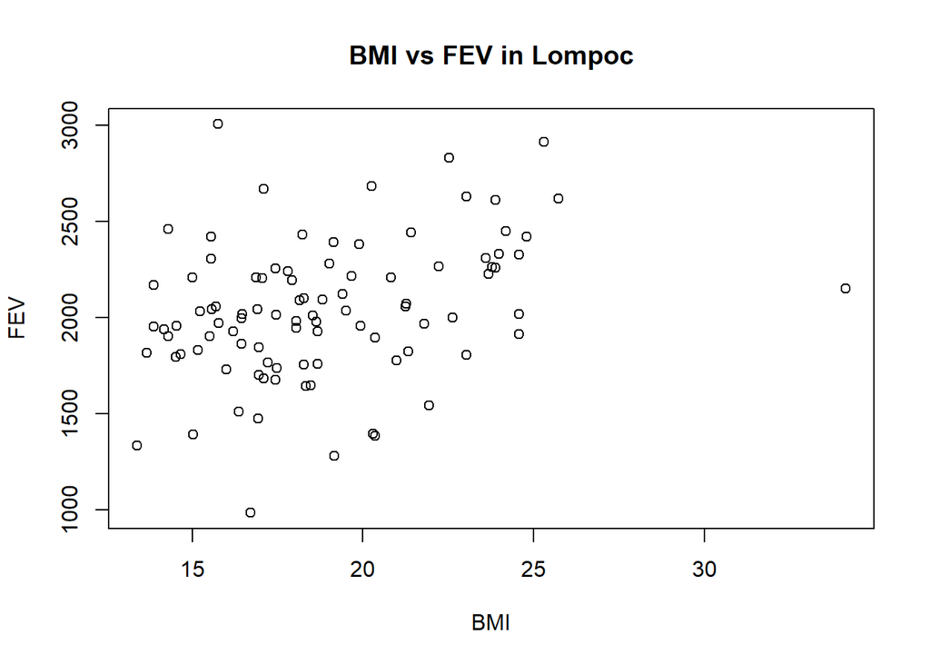

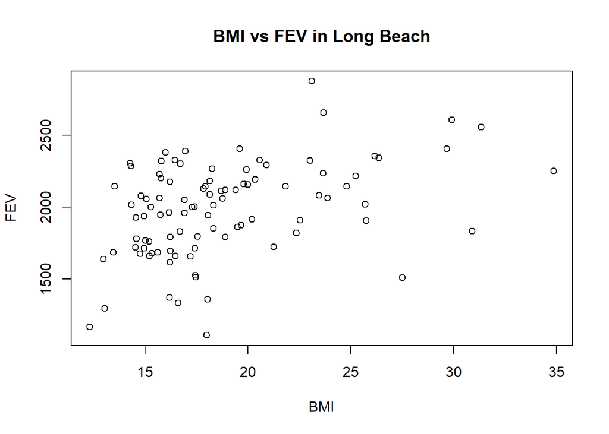

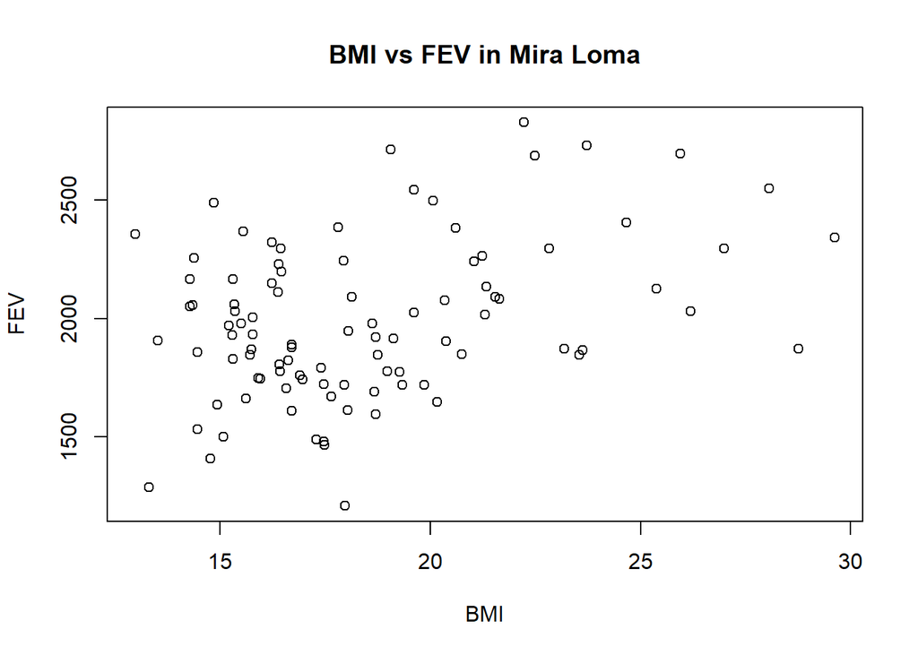

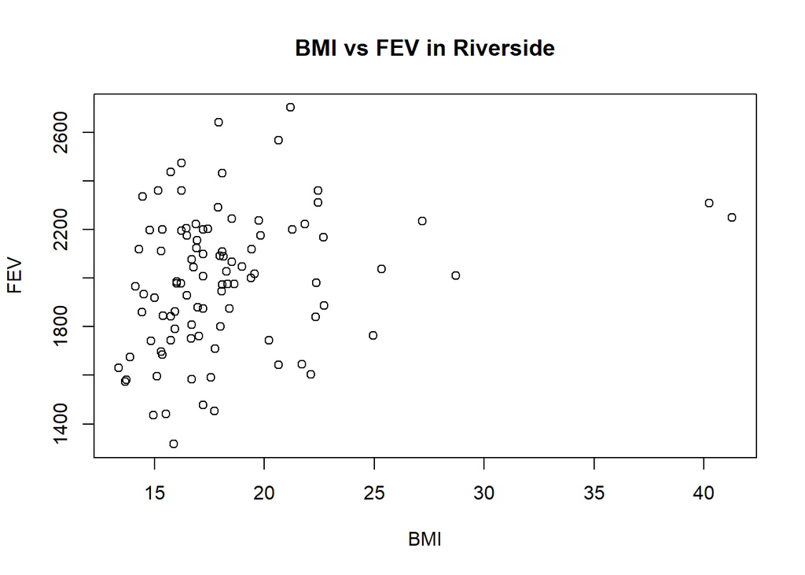

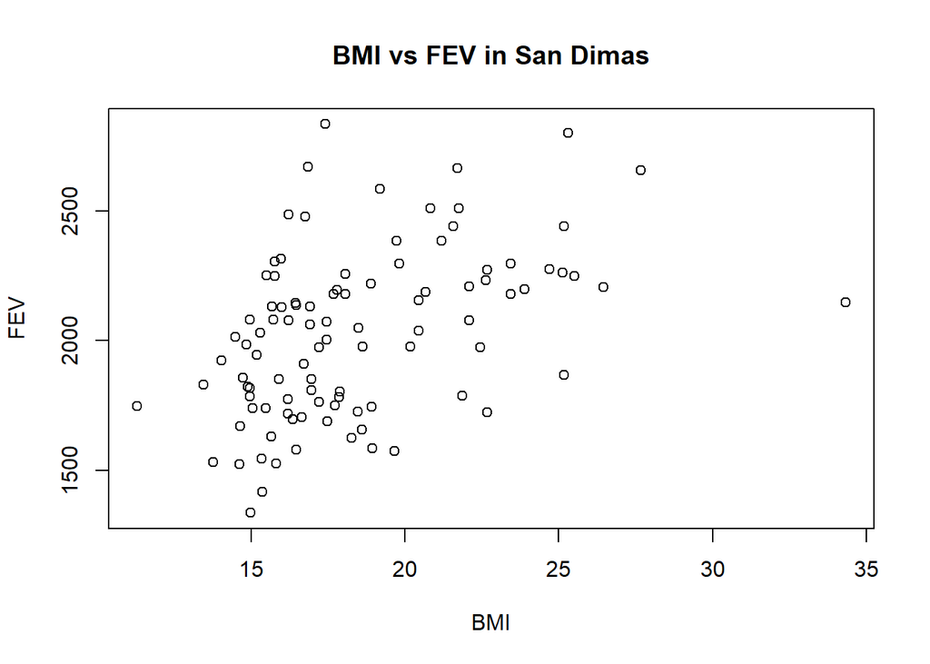

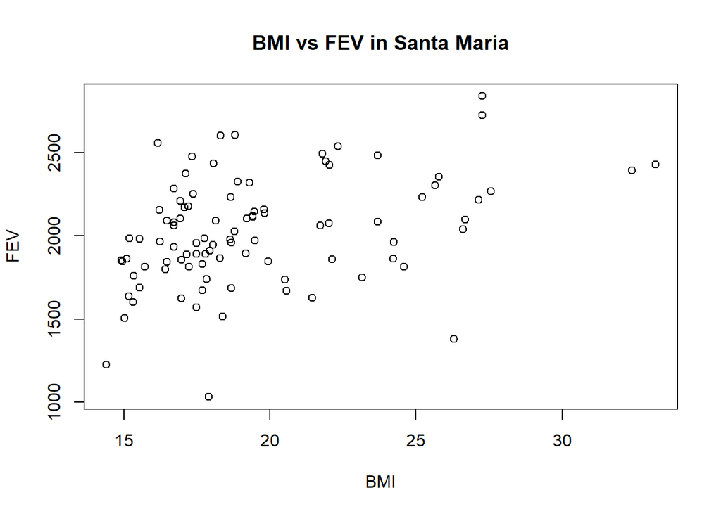

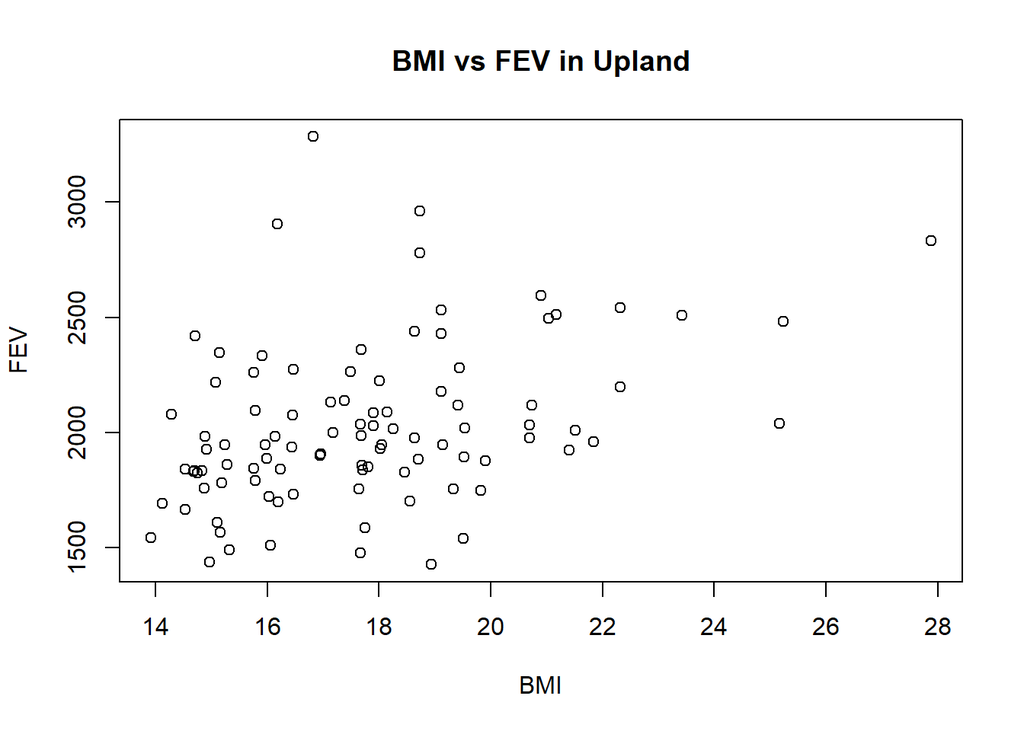

```r
town_data <- split(merged_chs, merged_chs$townname)

for (town in names(town_data)) {
  plot(town_data[[town]]$bmi, town_data[[town]]$fev,
       main=paste("BMI vs FEV in", town),
       xlab="BMI", ylab="FEV")
}
```

In all of the towns, there appears to be a slightly positive correlation between BMI and FEV1. This can be seen as the BMI increases the overall spread of the points shifts upwards meaning that as BMI increases, FEV1 is expected to increase.

### Part 2

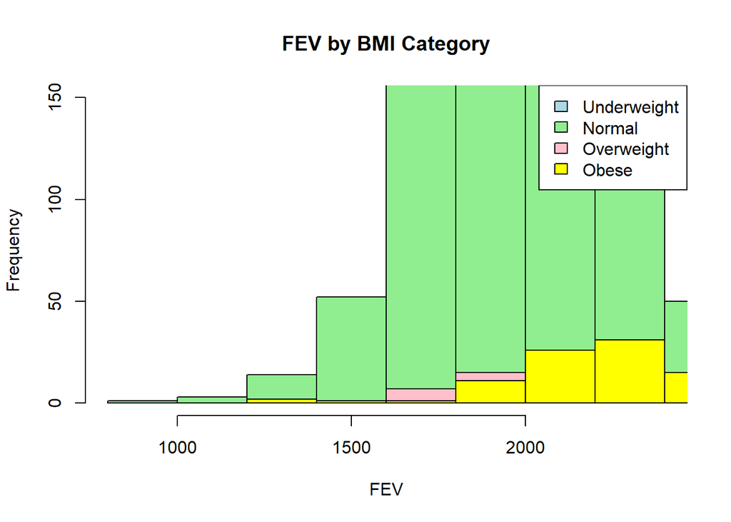

```r
bmi_data <- split(merged_chs, merged_chs$obesity_level)

hist(bmi_data$Underweight$fev, col = "lightblue", main = "FEV by BMI Category",
     xlab = "FEV", ylim = c(0, 150))

hist(bmi_data$Normal$fev, col = "lightgreen", add = TRUE)
hist(bmi_data$Overweight$fev, col = "pink", add = TRUE)
hist(bmi_data$Obese$fev, col = "yellow", add = TRUE)

legend("topright", legend = c("Underweight", "Normal", "Overweight", "Obese"),
       fill = c("lightblue", "lightgreen", "pink", "yellow"))
```

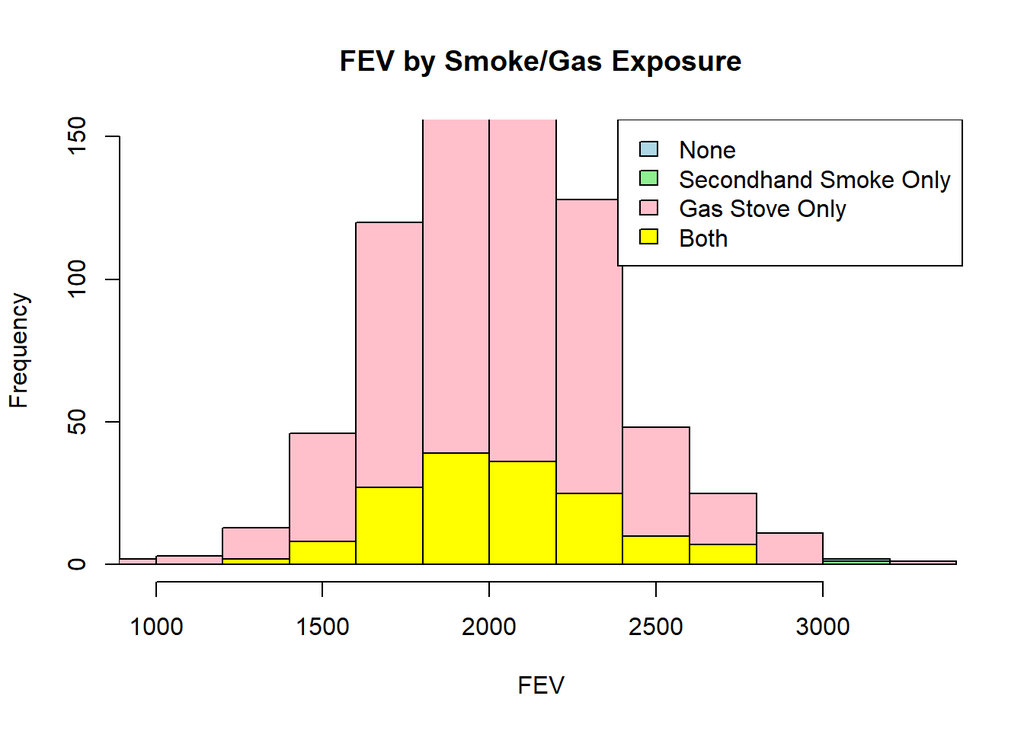

```r
smoke_gas_data <- split(merged_chs, merged_chs$smoke_gas_exposure)

hist(smoke_gas_data$None$fev, col="lightblue", main="FEV by Smoke/Gas Exposure",
     xlab="FEV", ylim=c(0, 150), xlim=c(min(merged_chs$fev), max(merged_chs$fev)))

hist(smoke_gas_data$`Secondhand Smoke Only`$fev, col="lightgreen", add=TRUE)
hist(smoke_gas_data$`Gas Stove Only`$fev, col="pink", add=TRUE)
hist(smoke_gas_data$Both$fev, col="yellow", add=TRUE)

legend("topright", legend=c("None", "Secondhand Smoke Only", "Gas Stove Only", "Both"),
       fill=c("lightblue", "lightgreen", "pink", "yellow"))
```

The FEV1s for “Normal” BMI participants was more frequently in the upper range than overweight and obese subjects. This could be due to more of the participants being in the normal range.

Similarly, it seemed that only being exposed to a gas stove resulted in more frequent higher FEV1s when compared to both and secondhand smoke only.

### Part 3

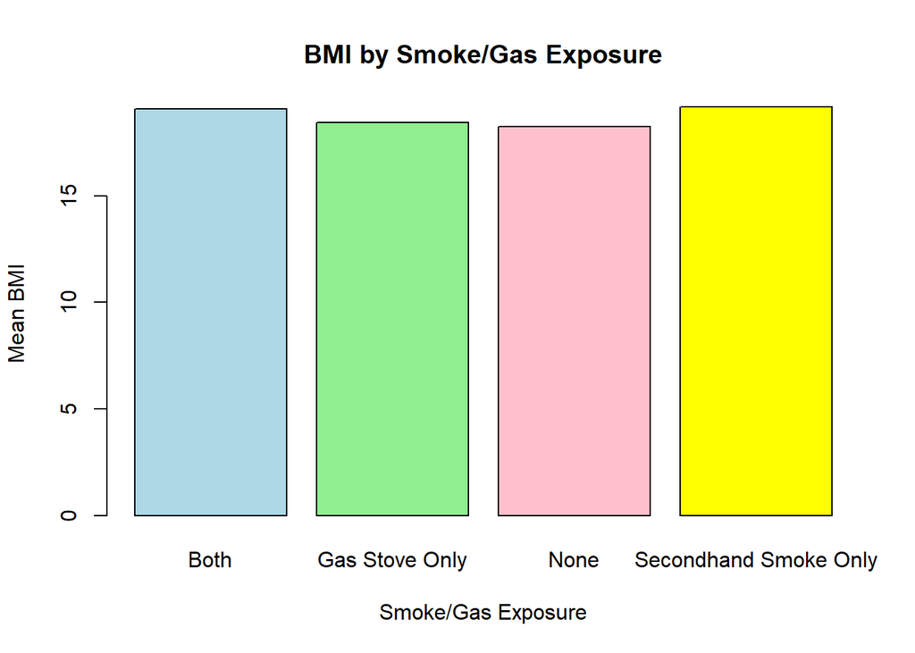

```r
mean_bmi <- tapply(merged_chs$bmi, merged_chs$smoke_gas_exposure, mean, na.rm = TRUE)

barplot(mean_bmi,
        main = "BMI by Smoke/Gas Exposure",
        xlab = "Smoke/Gas Exposure",
        ylab = "Mean BMI",
        col = c("lightblue", "lightgreen", "pink", "yellow"))
```

Overall it does not look like the mean BMI among the 4 exposure groups does not change very much. Having no exposures to both smoke and gas though did have the lowest mean BMI.

### Part 4

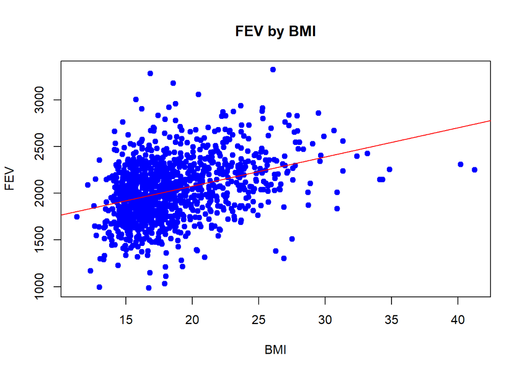

```r
plot(merged_chs$bmi, merged_chs$fev,
     main = "FEV by BMI",
     xlab = "BMI",
     ylab = "FEV",
     pch = 19, col = "blue")

# Add a regression line
abline(lm(fev ~ bmi, data = merged_chs), col = "red")
```

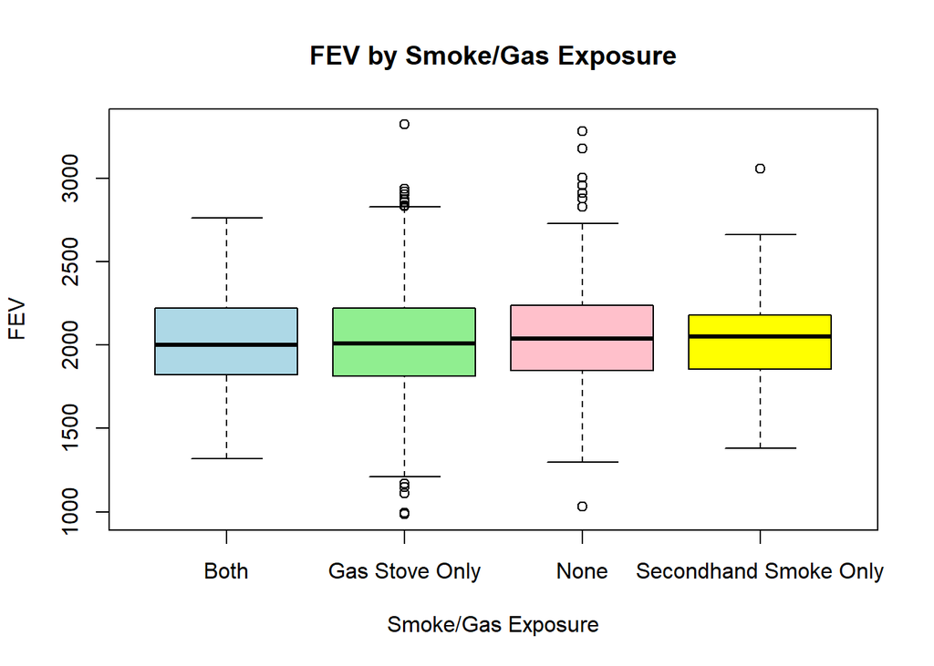

```r
boxplot(merged_chs$fev ~ merged_chs$smoke_gas_exposure,
        main = "FEV by Smoke/Gas Exposure",
        xlab="Smoke/Gas Exposure",
        ylab="FEV",
        col=c("lightblue", "lightgreen", "pink", "yellow"))
```

Overall again, there seems to be a positive correlation between BMI and FEV1 meaning that as BMI increases, FEV1 is expected to increase too. The boxplots showing FEV1 by smoking status do not indicate any significant differences between the groups as most of their data overlap.

### Part 5

```r
leaflet(data = merged_chs) %>%
  addTiles() %>%
  addCircleMarkers(~lon, ~lat,
                   radius = 5,
                   color = ~ifelse(pm25_mass > 20, "red",
                            ifelse(pm25_mass > 15, "orange",
                            ifelse(pm25_mass > 10, "yellow", "green"))),
                   fillOpacity = 0.7,
                   popup = ~paste("PM2.5 Mass:", pm25_mass)) %>%
  addLegend("bottomright",
            colors = c("green", "yellow", "orange", "red"),
            labels = c("<= 10", "10 - 15", "15 - 20", "> 20"),
            title = "PM2.5 Levels")
```

[interactive chart not shown]

Based on the leaflet map, it appears that there are higher concentrations of PM2.5 mass closer to Pomona which are greater than 20 micrograms/m^3. The green which get more frequent farther from Corona/Pomona are less than 10 micrograms/m^3.

### Part 6

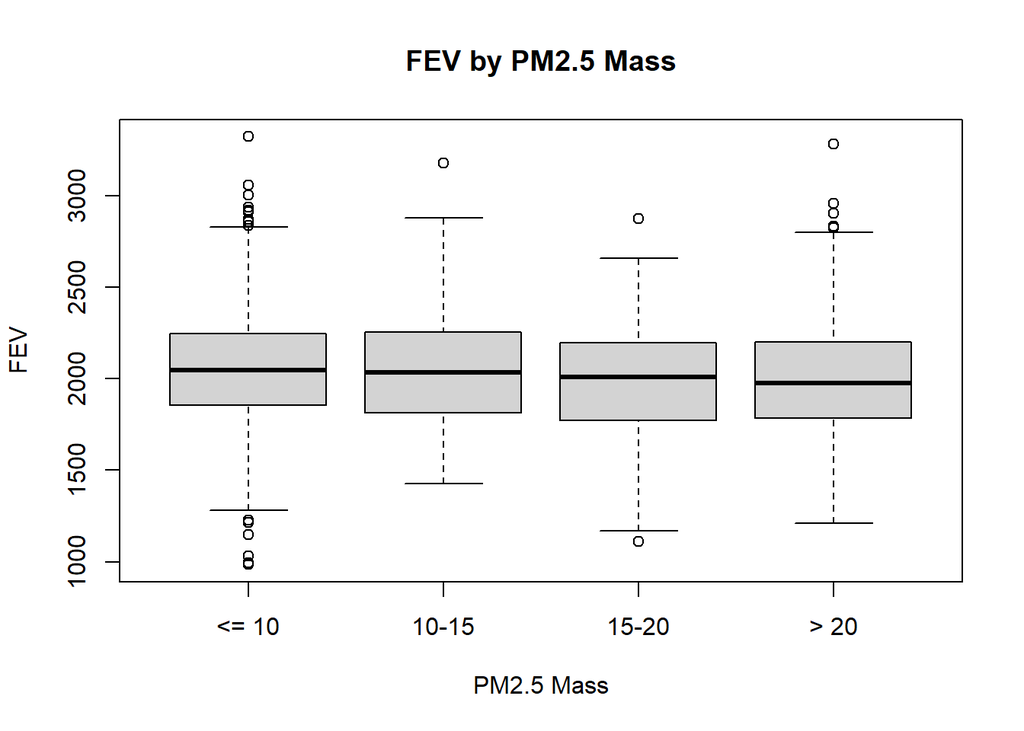

```r
merged_chs$pm25_bins <- cut(merged_chs$pm25_mass,
                            breaks = c(-Inf, 10, 15, 20, Inf),
                            labels = c("<= 10", "10-15", "15-20", "> 20"))

boxplot(merged_chs$fev ~ merged_chs$pm25_bins,
        main = "FEV by PM2.5 Mass",
        xlab = "PM2.5 Mass",
        ylab = "FEV")
```

Overall there does not seem to be a significant difference between the FEV1s for 4 different concentrations of PM2.5 mass. However, the median FEV1 for the participants that received <= 10 micrograms/cubic meter was the highest and > 20 micrograms/cubic meter was the lowest.